# Demographic Analysis of Norway

Economic Demography I Assignment

Andriy Zhubryd

června 2016

# 1 Introduction

This paper is focused on analysing Norway’s population and its changes in time. The following main areas will be covered in this paper:

All analyses are based on data from [Eurostat](http://ec.europa.eu/eurostat/web/population-demography-migration-projections/overview) and are performed in R.

Code parts are available in this report in the collapsed form and they can be explored by user. Some code elements are explained in the Appendix. Also, raw data description and samples are provided in the Appendix.

# 2 Population size and structure

## 2.1 Population size in time

First of all, we should look at the population size and its development in time. Here are plots and table showing Norway’s population in time:

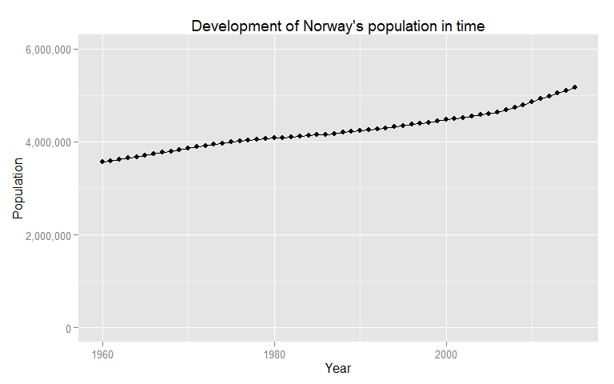

```r
dt_Population_Age_Sex %>%
  group_by(Year) %>% summarize(Population = sum(Population, na.rm = T)) %>%
  ggplot(aes(x = Year, y = Population)) + geom_point(size = 2) +
    geom_line() + scale_y_continuous(limits = c(0, 6*10^6), labels = comma) +
    ggtitle("Development of Norway's population in time")
```

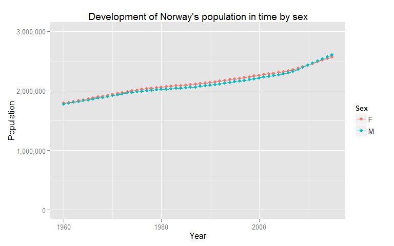

```r
dt_Population_Age_Sex %>%
  group_by(Year, Sex) %>% summarize(Population = sum(Population, na.rm = T)) %>%
  ggplot(aes(x = Year, y = Population, color = Sex)) + geom_point(size = 2) +
  geom_line() + scale_y_continuous(limits = c(0, 3*10^6), labels = comma) +
  ggtitle("Development of Norway's population in time by sex")
```

```r
dt_Population_Age_Sex %>%
  group_by(Year, Sex) %>% summarize(Population = sum(Population, na.rm = T)) %>%
  dcast(Year ~ Sex, fun.aggregate = sum, value.var = "Population") %>%
  mutate(Total = M + F) %>% filter(Year >= 2000) %>%
  mutate(Total = comma(Total) , M = comma(M), F = comma(F))
```

```
##    Year         F         M     Total
## 1  2000 2,261,357 2,217,140 4,478,497
## 2  2001 2,272,135 2,231,301 4,503,436
## 3  2002 2,282,132 2,241,934 4,524,066
## 4  2003 2,296,145 2,256,107 4,552,252
## 5  2004 2,308,408 2,269,049 4,577,457
## 6  2005 2,322,293 2,284,070 4,606,363
## 7  2006 2,338,238 2,301,981 4,640,219
## 8  2007 2,355,346 2,325,788 4,681,134
## 9  2008 2,377,481 2,359,690 4,737,171
## 10 2009 2,404,199 2,395,053 4,799,252
## 11 2010 2,431,447 2,426,752 4,858,199
## 12 2011 2,459,456 2,460,849 4,920,305
## 13 2012 2,486,999 2,498,871 4,985,870
## 14 2013 2,515,367 2,535,908 5,051,275
## 15 2014 2,540,963 2,567,007 5,107,970
## 16 2015 2,567,291 2,599,202 5,166,493
```

As we can see from the graph, population is steadily growing: approximately `45%` in `55` years, which makes up for `0.67%` increase per annum. In 1960 population comprised around `3.5` mln people and as of 2015 it’s nearly `5.2` mln people.

Also, we can see from the second graph that number of males and females is nearly the same throught the history. More detailed analysis of this will be in the following section.

## 2.2 Population age structure

Best way to analyze population strucure is to start with the age-sex pyramid graph. Pyramid graph stores the nation’s history and to confirm that we will build graphs for different years: 1960, 1980, 2000 and 2013.

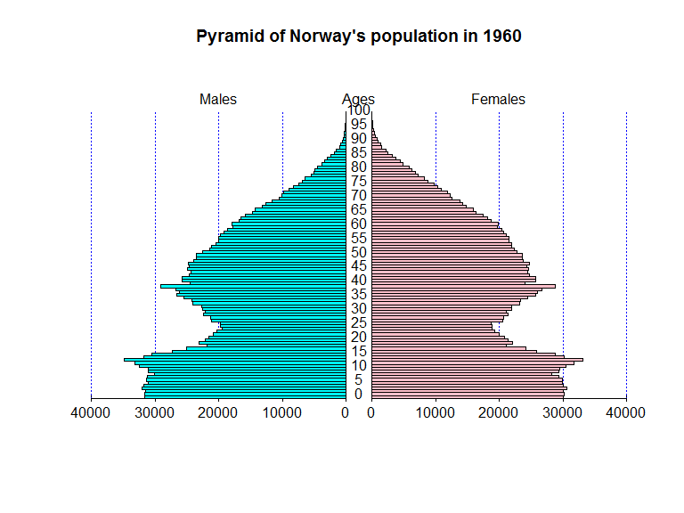

```r
dt_Population_Age_Sex %>%
  filter(Year == 1960) %>% group_by(Age, Sex) %>% summarise(value = sum(Population, na.rm = T)) %>%
  dcast(Age ~ Sex, fun.aggregate = sum, value.var = "value") %>% select(M, F, Age) %>%
  pyramid(Csize = 1, Cstep = 5, AxisFM = 'd', Cgap = .1, Laxis = 10^4 * 0:4,
          main = "Pyramid of Norway's population in 1960")
```

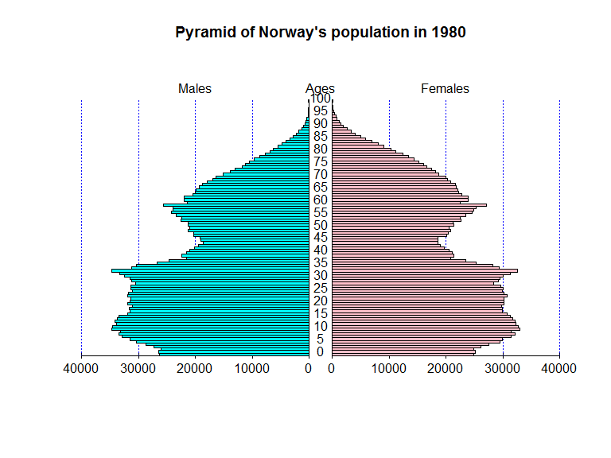

```r
dt_Population_Age_Sex %>%
  filter(Year == 1980) %>% group_by(Age, Sex) %>% summarise(value = sum(Population, na.rm = T)) %>%
  dcast(Age ~ Sex, fun.aggregate = sum, value.var = "value") %>% select(M, F, Age) %>%
  pyramid(Csize = 1, Cstep = 5, AxisFM = 'd', Cgap = .1, Laxis = 10^4 * 0:4,
          main = "Pyramid of Norway's population in 1980")
```

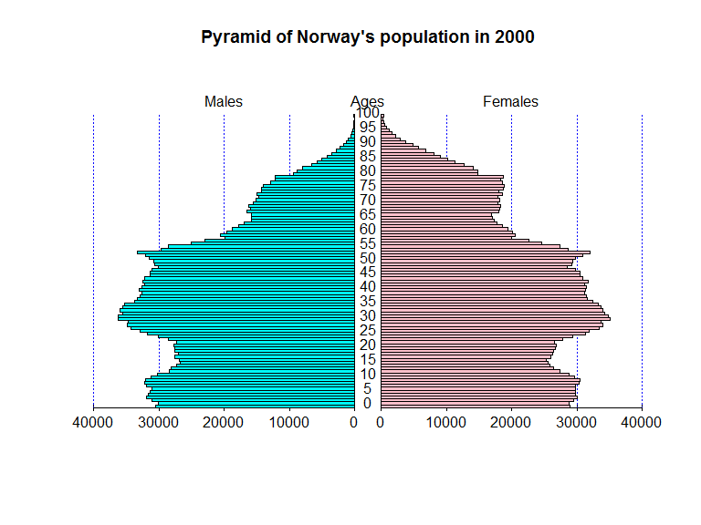

```r
dt_Population_Age_Sex %>%
  filter(Year == 2000) %>% group_by(Age, Sex) %>% summarise(value = sum(Population, na.rm = T)) %>%
  dcast(Age ~ Sex, fun.aggregate = sum, value.var = "value") %>% select(M, F, Age) %>%
  pyramid(Csize = 1, Cstep = 5, AxisFM = 'd', Cgap = .1, Laxis = 10^4 * 0:4,
          main = "Pyramid of Norway's population in 2000")
```

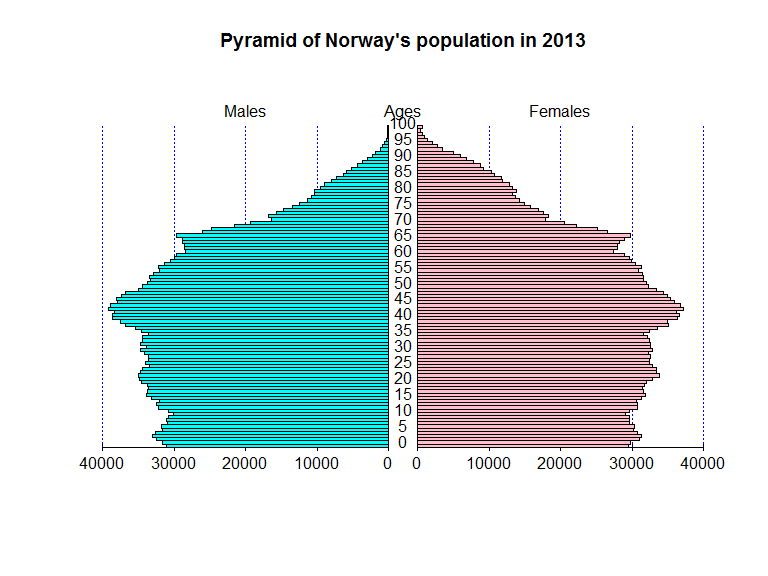

```r
dt_Population_Age_Sex %>%
  filter(Year == 2013) %>% group_by(Age, Sex) %>% summarise(value = sum(Population, na.rm = T)) %>%
  dcast(Age ~ Sex, fun.aggregate = sum, value.var = "value") %>% select(M, F, Age) %>%
  pyramid(Csize = 1, Cstep = 5, AxisFM = 'd', Cgap = .1, Laxis = 10^4 * 0:4,
          main = "Pyramid of Norway's population in 2013")
```

From the pyramid graphs you can see that peaks and gaps of generations are transferring to the further years. Pyramid is actually moving up with time.

We can notice that population was between progressive and stationary in 1960 with significant share of young generation. Currently (2013), we can say that population moved more to the regressive type with more or less stabel distribution of population up to age of 70. This kind of transformation is the natural process due to development of country and living conditions.

In addition, let’s show the change of index of masculinity (proportion of males to females) with the age increase:

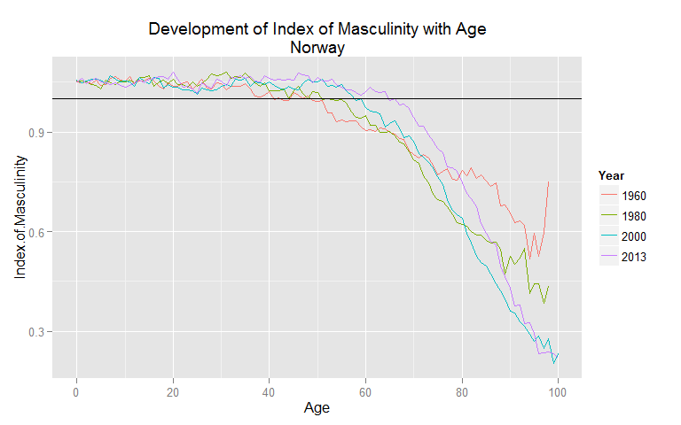

```r
dt_Population_Age_Sex %>%
  filter(Year %in% c(1960, 1980, 2000, 2013)) %>% group_by(Year, Age, Sex) %>%
  summarize(value = sum(Population, na.rm = T)) %>%
  dcast(Year + Age ~ Sex, fun.aggregate = sum, value.var = "value") %>%
  mutate(Index.of.Masculinity = M/F, Year = factor(Year)) %>%
  ggplot(aes(x = Age, y = Index.of.Masculinity, color = Year)) +
  geom_line() + geom_hline(yintercept = 1, size = .2) +
  ggtitle("Development of Index of Masculinity with Age\nNorway") +
  scale_x_continuous(breaks = 20*0:5, labels = 20*0:5)
```

From this graph we can make the following conclusions:

1. There are more males at the younger age
2. Proportion of males to females is decreasing with age
3. Parity point’s age (equal number of males and females) is increasing with time: from nearly 40 in 1960 to 58 in 2000 and 65 in 2013

This means that mortality rate for males is higher, but it’s decreasing in time quicker than for females.

## 2.3 Generations

### 2.3.1 Biological Generations

Biological generations are:

- children (0-14 years)
- parents (15-49 years)
- grandparents (50+ years)

Here’s the graph of development of biological generations in time and detail information about biological generations in 2013:

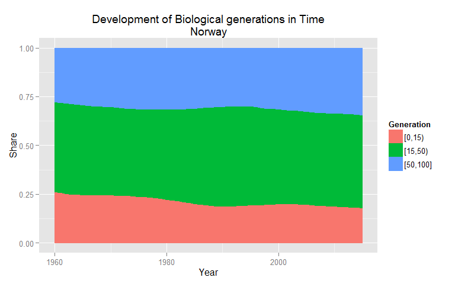

```r
tmp_Population_Age_Sex_Gen <- dt_Population_Age_Sex %>%
  mutate(Gen_bio = cut(Age, include.lowest = T, breaks = c(0, 15, 50, 100), right = F),
         Gen_eco = cut(Age, include.lowest = T, breaks = c(0, 20, 65, 100), right = F))

tmp_Bio_Generation <- tmp_Population_Age_Sex_Gen %>%
  group_by(Year, Generation = Gen_bio) %>% summarize(Value = sum(Population, na.rm = T)) %>%
  merge(dt_Population_Age_Sex %>% group_by(Year) %>% summarize(pop = sum(Population, na.rm = T)), by = "Year") %>%
  mutate(Share = Value/pop) %>% select(Year, Generation, Share)

tmp_Bio_Generation %>%
  ggplot(aes(x = Year, y = Share, color = Generation, fill = Generation)) +
    geom_area() + ggtitle("Development of Biological generations in Time\nNorway")
```

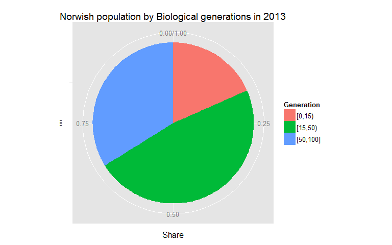

```r
tmp_Bio_Generation %>% filter(Year == 2013) %>%
  ggplot(aes(x = "", y = Share, fill = Generation)) +
    geom_bar(width = 1, stat = "identity") + coord_polar(theta = "y", start = 0) +
    ggtitle("Norwish population by Biological generations in 2013")
```

```r
tmp_Bio_Generation %>% filter(Year == 2013) %>% mutate(Share = round(Share*100, digits = 1))
```

```
##   Year Generation Share
## 1 2013     [0,15)  18.4
## 2 2013    [15,50)  47.8
## 3 2013   [50,100]  33.9
```

From the graphs we see that:

- Share of younger generation is constantly decreasing from `25%` in 1960 to `18.4%` in 2013
- In the meanwhile, share of older generation is increasing with approximately the same speed, which is causing steady upward trend of Sauvy’s index (shown later)
- Medium generation (parents) is more or less constant in time and volatiles around `47.57%` of population

We can conclude from these numbers that Norway moved from stationary type of population in 1960 to regressive one.

### 2.3.2 Economical generations

Same transformations we’ll perform for economical generations with slighly different age ranges:

- pre-productive (0-19 years)
- productive (20-64 years)
- post-productive (65+ years)

Development in time of shares of economical generations is shown below:

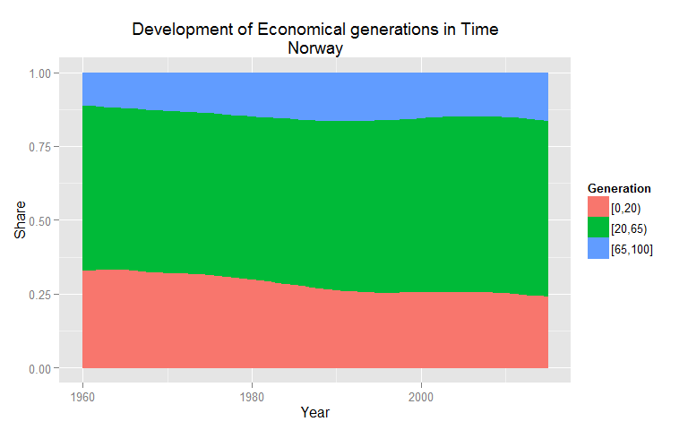

```r
tmp_Eco_Generation <- tmp_Population_Age_Sex_Gen %>%
  group_by(Year, Generation = Gen_eco) %>% summarize(Value = sum(Population, na.rm = T)) %>%
  merge(dt_Population_Age_Sex %>% group_by(Year) %>% summarize(pop = sum(Population, na.rm = T)), by = "Year") %>%
  mutate(Share = Value/pop) %>% select(Year, Generation, Share)

tmp_Eco_Generation %>%
  ggplot(aes(x = Year, y = Share, color = Generation, fill = Generation)) +
  geom_area() + ggtitle("Development of Economical generations in Time\nNorway")
```

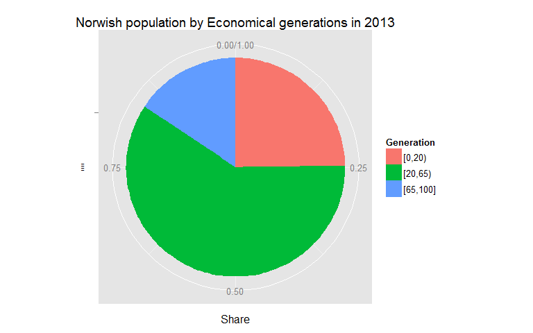

```r
tmp_Eco_Generation %>% filter(Year == 2013) %>%
  ggplot(aes(x = "", y = Share, fill = Generation)) +
  geom_bar(width = 1, stat = "identity") + coord_polar(theta = "y", start = 0) +
  ggtitle("Norwish population by Economical generations in 2013")
```

```r
tmp_Eco_Generation %>% filter(Year == 2013) %>% mutate(Share = round(Share*100, digits = 1))
```

```
##   Year Generation Share
## 1 2013     [0,20)  24.8
## 2 2013    [20,65)  59.5
## 3 2013   [65,100]  15.7
```

Similarly to biological generation, we see that:

- Share of pre-productive generation is constantly decreasing from, while share of post-productive is increasing with approximately the same speed. This is causing constant increase of ratio of seniority
- Productive generation is more or less constant in time with slight upward trend and average `57%` of population during last 55 years.

This means that total dependency ratio is slightly decreasing in time, mostly due to decrease of young-age dependency ratio.

### 2.3.3 Indicators

Now we will calculate all the indicators, which are applicable to biological and economical generations and interpret their meaning. Also, we will show development of those indicators in time:

```r
Ratios <- tmp_Population_Age_Sex_Gen %>% #filter (Year >= 2000) %>%
    dcast(Year ~ Sex, value.var = "Population", fun.aggregate = sum, na.rm = T) %>%
    mutate(Im = M/F, If = F/M) %>% select(Year, Im, If)

Ratios <- tmp_Bio_Generation %>% #filter(Year >= 2000) %>%
    dcast(Year ~ Generation, value.var = "Share", fun.aggregate = sum, na.rm = T) %>%
    setNames(c("Year", "I", "II","III")) %>% return %>%
    mutate(Sauvy = III/I) %>% select(Year, Sauvy) %>% merge(Ratios, by = "Year")

Ratios <- tmp_Eco_Generation %>% #filter(Year >= 2000) %>%
  dcast(Year ~ Generation, value.var = "Share", fun.aggregate = sum, na.rm = T) %>%
  setNames(c("Year", "I", "II","III")) %>% return %>%
  mutate(TDR = (I+III)/II, OADR = III/II, JADR = I/II, Seniority = III/I) %>%
  select(-I,-II,-III) %>% merge(Ratios, by = "Year")

Ratios %>% filter((Year %% 10 == 0) | Year > 2000) %>% melt(id = c("Year")) %>%
  mutate(value = round(value, 3)) %>% dcast(Year ~ variable)
```

```
##    Year   TDR  OADR  JADR Seniority Sauvy    Im    If
## 1  1960 0.785 0.195 0.590     0.330 1.068 0.993 1.007
## 2  1970 0.822 0.233 0.589     0.396 1.232 0.990 1.010
## 3  1980 0.807 0.265 0.542     0.489 1.405 0.983 1.017
## 4  1990 0.748 0.285 0.462     0.617 1.589 0.978 1.022
## 5  2000 0.699 0.259 0.440     0.589 1.571 0.980 1.020
## 6  2001 0.695 0.256 0.440     0.581 1.577 0.982 1.018
## 7  2002 0.692 0.253 0.439     0.575 1.589 0.982 1.018
## 8  2003 0.688 0.250 0.439     0.570 1.602 0.983 1.018
## 9  2004 0.687 0.249 0.439     0.567 1.624 0.983 1.017
## 10 2005 0.687 0.248 0.439     0.566 1.651 0.984 1.017
## 11 2006 0.686 0.248 0.438     0.566 1.681 0.984 1.016
## 12 2007 0.683 0.246 0.437     0.565 1.711 0.987 1.013
## 13 2008 0.679 0.246 0.434     0.567 1.735 0.993 1.008
## 14 2009 0.676 0.246 0.430     0.572 1.755 0.996 1.004
## 15 2010 0.678 0.250 0.428     0.583 1.774 0.998 1.002
## 16 2011 0.678 0.253 0.425     0.596 1.795 1.001 0.999
## 17 2012 0.679 0.259 0.420     0.615 1.822 1.005 0.995
## 18 2013 0.680 0.263 0.417     0.631 1.844 1.008 0.992
## 19 2014 0.681 0.267 0.413     0.647 1.870 1.010 0.990
## 20 2015 0.681 0.271 0.410     0.663 1.903 1.012 0.988
```

[figure not shown]

```r
## Development of ratios in time
# Masculinity index
Ratios %>% select(Year, Im, If) %>% melt(id = "Year") %>%
  setNames(c("Year", "Index", "Value")) %>% return %>%
  ggplot(aes(x = Year, y = Value, color = Index)) + geom_point() + geom_line() +
  ylim(c(0.9,1.1)) + ggtitle("Development of masculinity index in time\nGermany") +
  geom_vline(xintercept = 2011, size = 0.5, linetype = "longdash")
```

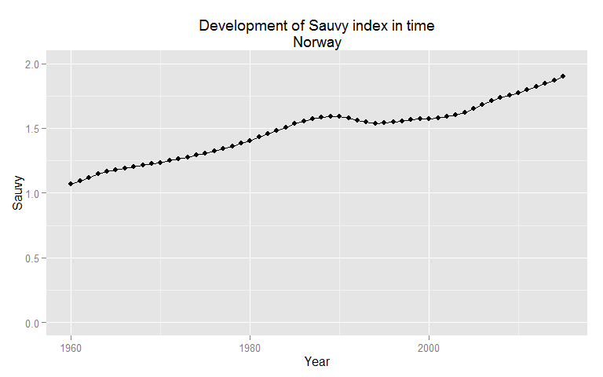

```r
# Sauvy
ggplot(Ratios, aes(x = Year, y = Sauvy)) + geom_point() + geom_line() +
  ggtitle("Development of Sauvy index in time\nNorway") + ylim(c(0,2))
```

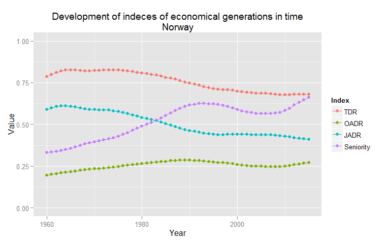

```r
# Economical generations
Ratios %>% select(Year, TDR, OADR, JADR, Seniority) %>% melt(id = "Year") %>%
  setNames(c("Year", "Index", "Value")) %>% return %>%
  ggplot(aes(x = Year, y = Value, color = Index)) + geom_point() + geom_line() +
  ylim(0:1) + ggtitle("Development of indeces of economical generations in time\nNorway")
```

Conclusions from three graphs and table above:

# 3 Population change

After analyzing population size and structure, which is based on annual snapshots, it is a logical step to look at what is happenning with the population between those snapshots: births, deaths, migration.

Here’s a general picture of those changes as percentage of the average population during the year:

```r
tmp_Population_General <- dt_Population_general %>%
  filter(!(Indicator %in% c("Average population", "Population Start"))) %>%
  group_by(Indicator, Year) %>% summarize(Value = sum(Value, na.rm = T)) %>%
  merge(dt_Population_general %>% filter(Indicator == "Average population") %>%
          group_by(Year) %>% summarize(Pop = sum(Value, na.rm = T)), by = "Year") %>%
  mutate(Value = round(Value/Pop*100, 3))

tmp_Population_General %>%
  dcast(Year ~ Indicator, fun.aggregate = sum, na.rm = T, value.var = "Value")
```

```
##    Year Deaths Live births Natural change Net migration
## 1  2000  0.980       1.318          0.339         0.216
## 2  2001  0.974       1.256          0.282         0.175
## 3  2002  0.980       1.221          0.242         0.379
## 4  2003  0.931       1.236          0.306         0.246
## 5  2004  0.897       1.240          0.343         0.286
## 6  2005  0.892       1.228          0.336         0.397
## 7  2006  0.885       1.256          0.371         0.507
## 8  2007  0.891       1.241          0.350         0.839
## 9  2008  0.875       1.269          0.394         0.908
## 10 2009  0.858       1.280          0.422         0.799
## 11 2010  0.849       1.257          0.408         0.862
## 12 2011  0.836       1.216          0.380         0.944
## 13 2012  0.837       1.201          0.364         0.939
## 14 2013  0.810       1.159          0.349         0.767
```

[output cut: 17 more lines]

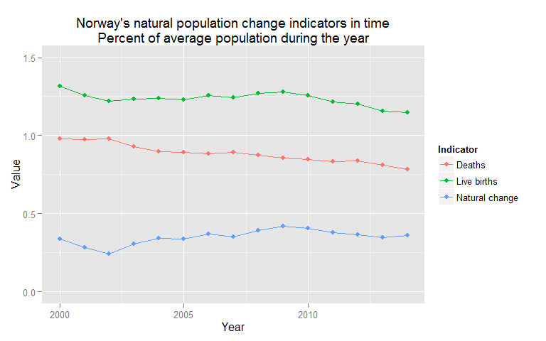

```r
tmp_Population_General %>%
  filter(!(Indicator %in% c("Net migration", "Total population change"))) %>%
  ggplot(aes(x = Year, y = Value, color = Indicator)) + geom_line() + geom_point() + ylim(c(0,1.5)) +
  ggtitle("Norway's natural population change indicators in time\nPercent of average population during the year")
```

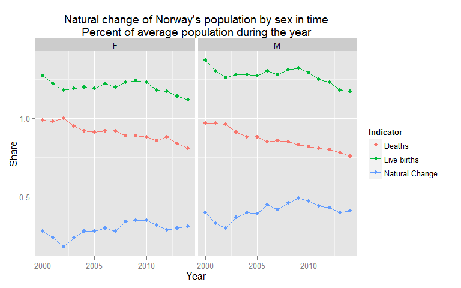

```r
dt_Population_general %>%
  filter(Indicator %in% c("Deaths", "Live births")) %>%
  group_by(Indicator, Year, SEX) %>% summarize(Value = sum(Value, na.rm = T)) %>%
  merge(dt_Population_general %>% filter(Indicator == "Average population") %>%
          group_by(Year, SEX) %>% summarize(Pop = sum(Value, na.rm = T)), by = c("Year", "SEX")) %>%
  mutate(Value = round(Value/Pop*100, 2)) %>%
  dcast(Year + SEX ~ Indicator, fun.aggregate = sum, value.var = "Value") %>%
  mutate(`Natural Change` = `Live births` - Deaths) %>% melt(id = c("Year", "SEX")) %>%
  setNames(c("Year", "Sex", "Indicator", "Share")) %>% return %>%
  ggplot(aes(x = Year, y = Share, color = Indicator)) + geom_line() + geom_point() + facet_grid(. ~ Sex) +
  ggtitle("Natural change of Norway's population by sex in time\nPercent of average population during the year")
```

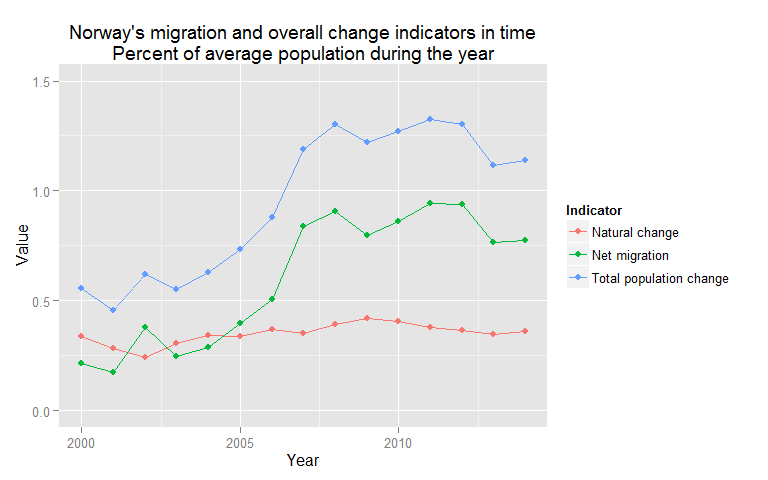

```r
tmp_Population_General %>% filter(Indicator %in% c("Net migration", "Total population change", "Natural change")) %>%
  ggplot(aes(x = Year, y = Value, color = Indicator)) + geom_line() + geom_point() + ylim(c(0,1.5)) +
  ggtitle("Norway's migration and overall change indicators in time\nPercent of average population during the year")
```

These graphs and table were supposed to give general impression on the influence of different factors on the change of Norway’s population. Preliminary conslusions are as follows:

1. Norway is constantly demonstating positive natural change of population (for the last 15 years). Death rate is steadily decreasing, while natality rate has slower decrease, which causes slow increase of natural change rate.
2. Major influence on total population change is cause by net migration. Since 2007, net migration is significantly higher than natural change (which is quite stable), so total population change is practically shadowing fluctuation of net migration.
3. Males demonstate slightly lower share of deaths and higher level of births, which results in higher positive level of natural population change. Also, this explains the change in the index of masculinity in the section above.

# 4 Fertility

# 5 Mortality

# 6 Migration

# 7 Marriage

# 8 Education

# 9 Life Tables

# 10 Projections

# 11 Conclusions

# 12 Appendix

## 12.1 Used libraries

Here’s the list of libraries used during this assignment:

```r
library(dplyr)      # Work with datasets: filter, group, summarize
library(reshape2)   # Transformation of datasets: wide-to-long format and vice versa
library(pyramid)    # Visualization of demography pyramid
library(ggplot2)    # Building graphs
library(scales)     # Number formatting
```

## 12.2 Explanation of code parts

`%>%` element is called chaining operator and is a part of *dplyr* package. This operator is handing element on the left to the function on the right as the first argument. It helps to make complicated nested formulas easier to comprehend:

```r
# Simple example
    filter(dataset, field == "value")
        # is equal to
    dataset %>% filter(field == "value")

# More complex example
    summarize(group_by(filter(dataset, field == "value"), group_field), function(value_field))
        # is equal to
    dataset %>% filter(field == "value") %>% group_by(group_field) %>% summarize(function(value_field))
```

As you can see from the second example, chaining operator makes your code much more easier to read. That’s why it’s used throughout the paper.

## 12.3 Source data

Following datasets from the [Eurostat](http://ec.europa.eu/eurostat/web/population-demography-migration-projections/overview) were used in this assignment:

Full tables are attached in the archive. Also, RData file `Eurostat.RData` contains all those source tables after import to R.

Here are 10 sample rows for each of the tables:

##### 12.3.0.0.1 dt_Population_general

```r
dt_Population_general %>% head(10)
```

```
##             Indicator SEX Year   Value
## 1  Average population   F 2000 2266746
## 2  Average population   F 2001 2277134
## 3  Average population   F 2002 2289139
## 4  Average population   F 2003 2302277
## 5  Average population   F 2004 2315351
## 6  Average population   F 2005 2330266
## 7  Average population   F 2006 2346792
## 8  Average population   F 2007 2366414
## 9  Average population   F 2008 2390840
## 10 Average population   F 2009 2417823
```

##### 12.3.0.0.2 dt_Population_Age_Sex

```r
dt_Population_Age_Sex %>% head(10)
```

```
##    Age Sex Year Population
## 1    1   M 1960      31676
## 2    1   M 1961      31644
## 3    1   M 1962      30897
## 4    1   M 1963      31646
## 5    1   M 1964      31353
## 6    1   M 1965      31761
## 7    1   M 1966      33324
## 8    1   M 1967      33540
## 9    1   M 1968      33862
## 10   1   M 1969      33585
```

##### 12.3.0.0.3 dt_Education

```r
dt_Education %>% head(10)
```

```
##    Age Sex Year       Education Count
## 1    0   M 2007 Lower.Secondary     0
## 2    0   M 2008 Lower.Secondary     0
## 3    0   M 2009 Lower.Secondary     0
## 4    0   M 2010 Lower.Secondary     0
## 5    0   M 2011 Lower.Secondary     0
## 6    0   M 2012 Lower.Secondary     0
## 7    0   M 2013 Lower.Secondary     0
## 8    0   M 2014 Lower.Secondary     0
## 9    1   M 2007 Lower.Secondary     0
## 10   1   M 2008 Lower.Secondary     0
```

##### 12.3.0.0.4 dt_Marital

```r
dt_Marital %>% head(10)
```

```
##    Age Sex Year Marsta Count
## 1    0   M 2000 Single 30485
## 2    1   M 2000 Single 30134
## 3    2   M 2000 Single 31151
## 4    3   M 2000 Single 31893
## 5    4   M 2000 Single 31595
## 6    5   M 2000 Single 31426
## 7    6   M 2000 Single 31138
## 8    7   M 2000 Single 31890
## 9    8   M 2000 Single 32192
## 10   9   M 2000 Single 32038
```

##### 12.3.0.0.5 dt_Marriage_Age

```r
dt_Marriage_Age %>% head(10)
```

```
##        Age Sex Year Count
## 1  [15;20)   M 2007    51
## 2  [15;20)   M 2008    46
## 3  [15;20)   M 2009    41
## 4  [15;20)   M 2010    34
## 5  [15;20)   M 2011    35
## 6  [15;20)   M 2012    31
## 7  [15;20)   M 2013    51
## 8  [15;20)   M 2014    22
## 9  [20;25)   M 2007  1273
## 10 [20;25)   M 2008  1270
```

##### 12.3.0.0.6 dt_Marriage_PrevStatus

```r
dt_Marriage_PrevStatus %>% head(10)
```

```
##     MARSTA Sex Year Count
## 1   Single   M 2007 17770
## 2   Single   M 2008 19091
## 3   Single   M 2009 18727
## 4   Single   M 2010 18092
## 5   Single   M 2011 17459
## 6   Single   M 2012 18499
## 7   Single   M 2013 17780
## 8   Single   M 2014 17529
## 9  Widowed   M 2008   318
## 10 Widowed   M 2009   285
```

##### 12.3.0.0.7 dt_Divorce

```r
dt_Divorce %>% head(10)
```

```
##    Indicator Year Value
## 1   Divorces 2000 10053
## 2   Divorces 2001 10308
## 3   Divorces 2002 10450
## 4   Divorces 2003 10757
## 5   Divorces 2004 11045
## 6   Divorces 2005 11040
## 7   Divorces 2006 10598
## 8   Divorces 2007 10280
## 9   Divorces 2008 10158
## 10  Divorces 2009 10235
```

##### 12.3.0.0.8 dt_Fertility

```r
dt_Fertility %>% head(10)
```

```
##                                     Indicator Year Value
## 1  Proportion of live births outside marriage 2000  49.6
## 2  Proportion of live births outside marriage 2001  49.7
## 3  Proportion of live births outside marriage 2002  50.3
## 4  Proportion of live births outside marriage 2003  50.0
## 5  Proportion of live births outside marriage 2004  51.4
## 6  Proportion of live births outside marriage 2005  51.8
## 7  Proportion of live births outside marriage 2006  53.0
## 8  Proportion of live births outside marriage 2007  54.5
## 9  Proportion of live births outside marriage 2008  55.0
## 10 Proportion of live births outside marriage 2009  55.1
```

##### 12.3.0.0.9 dt_Fertility_Rate

```r
dt_Fertility_Rate %>% head(10)
```

```
##    Age Year Fertility_Rate
## 1   15 2000        0.00066
## 2   15 2001        0.00046
## 3   15 2002        0.00055
## 4   15 2003        0.00046
## 5   15 2004        0.00051
## 6   15 2005        0.00026
## 7   15 2006        0.00029
## 8   15 2007        0.00045
## 9   15 2008        0.00042
## 10  15 2009        0.00045
```

##### 12.3.0.0.10 dt_Death_Age

```r
dt_Death_Age %>% head(10)
```

```
##    Age Sex Year Deaths
## 1    0   M 2000    130
## 2    0   M 2001    126
## 3    0   M 2002     94
## 4    0   M 2003    105
## 5    0   M 2004     99
## 6    0   M 2005     95
## 7    0   M 2006    111
## 8    0   M 2007     97
## 9    0   M 2008    101
## 10   0   M 2009    119
```

##### 12.3.0.0.11 dt_Migration

```r
dt_Migration %>% head(10)
```

```
##    Age Sex Year Immigration Emigration Net_Migration
## 1    0   M 2013         635        136           771
## 2    0   M 2014         636        158           794
## 3    1   M 2013         662        175           837
## 4    1   M 2014         612        207           819
## 5    2   M 2013         570        213           783
## 6    2   M 2014         526        272           798
## 7    3   M 2013         491        205           696
## 8    3   M 2014         493        295           788
## 9    4   M 2013         444        208           652
## 10   4   M 2014         437        250           687
```

##### 12.3.0.0.12 dt_Life_Table

```r
dt_Life_Table %>% head(10)
```

```
##    AGE Sex Year Survival
## 1    0   M 2000  0.99574
## 2    0   M 2001  0.99577
## 3    0   M 2002  0.99674
## 4    0   M 2003  0.99635
## 5    0   M 2004  0.99661
## 6    0   M 2005  0.99675
## 7    0   M 2006  0.99626
## 8    0   M 2007  0.99678
## 9    0   M 2008  0.99671
## 10   0   M 2009  0.99624
```